# 51 1602脚位图

2020-06-16 23:21:58

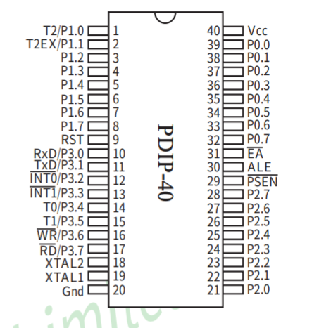

**1、主电源引脚（2根）** - VCC(Pin40)：电源输入，接＋5V电源 - GND(Pin20)：接地线

**3、控制引脚（4根）**

- RST/VPP(Pin9)：复位引脚，引脚上出现2个机器周期的高电平将使单片机复位。
- ALE/PROG(Pin30)：地址锁存允许信号
- PSEN(Pin29)：外部存储器读选通信号
- EA/VPP(Pin31)：程序存储器的内外部选通，接低电平从外部程序存储器读指令，如果接高电平则从内部程序存储器读指令。

**4、可编程输入/输出引脚（32根）** AT89S51单片机有4组8位的可编程I/O口，分别位P0、P1、P2、P3口，每个口有8位（8根引脚），共32根。每一根引脚都可以编程，比如用来控制电机、交通灯、霓虹灯等，开发产品时就是利用这些可编程引脚来实现我们想要的功能，尽情发挥你的想象力吧，实现你想要的：） 强大无比。。。

- PO口（Pin39～Pin32）：8位双向I/O口线，名称为P0.0～P0.7
- P1口（Pin1～Pin8）：8位准双向I/O口线，名称为P1.0～P1.7
- P2口（Pin21～Pin28）：8位准双向I/O口线，名称为P2.0～P2.7
- P3口（Pin10～Pin17）：8位准双向I/O口线，名称为P3.0～P3.7

http://www.stcmcudata.com/datasheet/stc/STC-AD-PDF/STC89C51RC-RD.pdf

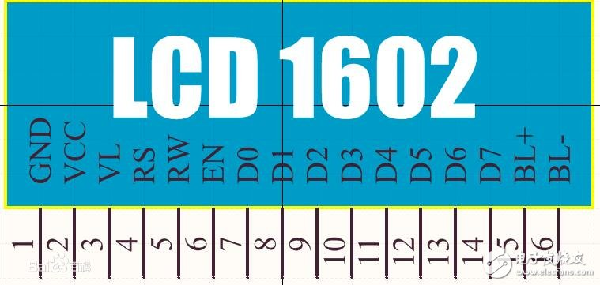

第1引脚：GND为电源地

第2引脚：VCC接5V电源正极

第3引脚：V0为液晶显示器对比度调整端，接正电源时对比度最弱，接地电源时对比度最高（对比度过高会 产生“鬼影”，使用时可以通过一个10K的电位器调整对比度）。

第4引脚：RS为寄存器选择，高电平1时选择数据寄存器、低电平0时选择指令寄存器。

第6引脚：E（或EN）端为使能（enable）端，高电平（1）时读取信息，负跳变时执行指令。

第7～14引脚：D0～D7为8位双向数据端。第15～16脚：空脚或背灯电源。第15引脚背光正极，第16引脚背光负极。